# COVID-19 Analyses

bayes

vaccines

Author

maj

Published

November 13, 2024

Modified

November 29, 2024

```r
library(data.table)
library(ggplot2)
library(gt)
```

Vaccine efficacy is defined as:

$$VE = 1\left(1 - \frac{\pi_v}{\pi_p} \right)$$

where $\pi_v$, $\pi_p$ are the probabilities of infection under the vaccine and placebo (i.e. the risk of infection without vaccination), generally expressed as a percentage.

The lower the risk of infection on receipt of the vaccine relative to the risk of infection under placebo, the higher the VE with VE capped at 100%, $\lim_{\pi_v \to 0} VE = 1$. For the FDA to approve a vaccine, the VE must be at least 0.3 (30%).

If we can reasonably assume that $\pi_v \le \pi_p$ (implying the risk of infection is going to be lower on receipt of the vaccine than on placebo) then the lower bound of VE will be constrained to zero. However, when we cannot make this assumption and $\pi_v > \pi_p$ then VE may become negative.

The VE is given various representations via the risk-ratio, incidence rate ratio and hazard ratio, specifically:

$$\begin{aligned}
VE &= 1 - RR = 1 - \frac{c_v/N_v}{c_p/N_p} \\
VE &= 1 - IRR = 1 - \frac{c_v/T_v}{c_p/T_p} \\
VE &= 1 - HR = 1 - \frac{\lambda_v}{\lambda_p}
\end{aligned}$$

where $c_.$ are the cases and $N_.$ are the total number of participants, $T_.$ is person-time and $\lambda_.$ are hazard rates.

If we take the second representation and set $r = T_v/T_p$ as the ratio of person-time, then a few manipulations give us:

$$\frac{c_v}{c_p} = r (1 - VE)$$

from which we can form a *case proportion* - the proportion of the total cases in the vaccinated group:

$$\begin{aligned}
\theta &= \frac{r (1 - VE)}{1 + r(1 - VE)} \\
&= \frac{ \frac{c_v}{c_p} }{ \frac{c_v}{c_p} + 1 } \\
&= \frac{ \frac{c_v}{c_p} }{ \frac{c_v}{c_p} + \frac{c_p}{c_p} } \\
&= \frac{ c_v }{ c_v + c_p }
\end{aligned}$$

which is a proportion between 0 and 1, and thus might plausibly admit to a beta distributional assumption.

Some more manipulations gives a reparameterisation of VE:

$$\begin{aligned}
\frac{1 + r(1 - VE)}{r (1 - VE)} &= \frac{1}{\theta} \\
\frac{1}{r (1 - VE)} + 1 &= \frac{1}{\theta} \\
&= \frac{1-\theta}{\theta}\\
r (1 - VE) &= \frac{\theta}{1-\theta} \\
1 - VE &= \frac{\theta}{r(1-\theta)} \\
VE - 1 &= - \frac{\theta}{r(1-\theta)} \\
&= \frac{\theta}{r(\theta-1)} \\
VE &= 1 + \frac{\theta}{r(\theta-1)}
\end{aligned}$$

and therefore we can do inference on $\theta$ and derive VE from that.

According to [this](https://www.nejm.org/doi/full/10.1056/NEJMoa2034577) paper by Polack, there were 8 cases in the vaccine group and 162 in the placebo group used in the Pfizer vaccine efficacy analysis. Additionally, the follow up times were 2.214 and 2.222 in 1000 person-years in the vaccine and placebo groups respectively.

Therefore, we can compute the posterior on the case proportion as $\theta \sim \text{Beta}(8 + 0.700102, 162 + 1)$ and derive VE. By simulation:

```r
N_ptcl <- 1e6

# person time followup ratio
r <- 2.214 / 2.222

# prior
theta_pri <- rbeta(N_ptcl, 0.700102, 1)
mu_theta_pri <- 0.700102 / (1 + 0.700102)
VE_pri <- 1 + theta_pri / (1 * (theta_pri - 1))

# posterior
theta <- rbeta(N_ptcl, 8 + 0.700102, 162 + 1)
VE <- 1 + theta / (r * (theta - 1))


# results
d_theta <- data.table(par = "theta", prior = theta_pri, posterior = theta)
d_VE <- data.table(par = "VE", prior = VE_pri, posterior = VE)
```

Figure 1 shows the prior and posterior on the case proportion, Figure 2 shows the implied VE and Table 1 gives a summary of the posterior on the VE parameter.

The prior on $\theta$, the case proportion, implies a prior probability that VE is greater than 0.3 equal to 0.54. However, the posterior probability that VE is greater than 0.3 is 1.00.

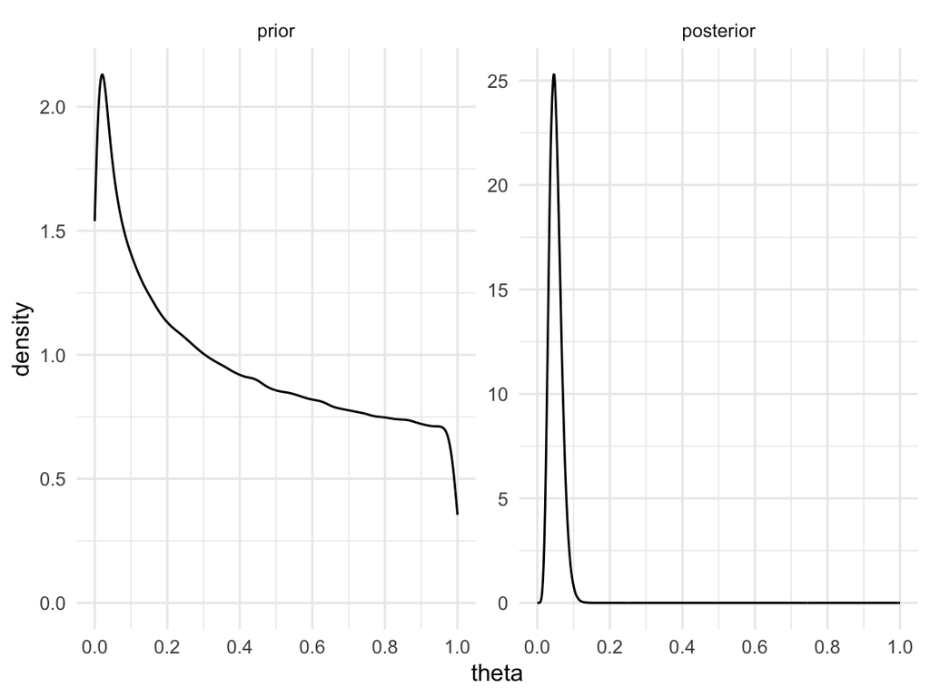

Figure 1: Prior and posterior density on case proportion

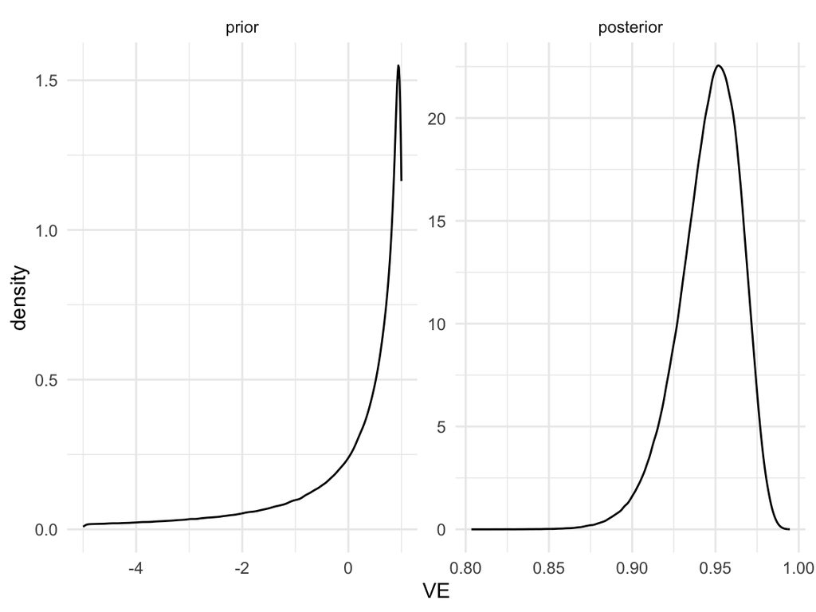

Figure 2: Prior and posterior density on VE

Table 1: Summary of posterior on VE

|  | Posterior (mean, 95% CrI) mean | Posterior (mean, 95% CrI) 2.5% | Posterior (mean, 95% CrI) 97.5% |
| --- | --- | --- | --- |
| VE | 0.946 | 0.903 | 0.976 |